# Performance Assessment Task 1 - Linear Regression Modeling

# ▶ Research Question

Our research questions is as follows: **What patient factors contributed to the highest total charge billed to the patient during their hospital stay.**.

```python
# Importing libraries
import pandas as pd
import seaborn as sns
import matplotlib.pyplot as plt
import numpy as np

from IPython.core.interactiveshell import InteractiveShell # Importing so we can run multiple lines in one cell
InteractiveShell.ast_node_interactivity = "all" # Code so multiple lines in one cell can be ran simultaenously

pd.set_option('display.max_columns', None)
pd.set_option('display.max_rows', None)
import warnings
warnings.filterwarnings('ignore')
```

```python
# Importing original dataset
df = pd.read_csv('F:/GitHub Repos/WGU_MSDA/D208_Predictive Modeling/medical_clean.csv')
```

# ▶ Data Cleaning

```python
# Showing first 5 records
df.head()
```

|  | CaseOrder | Customer_id | Interaction | UID | City | State | County | Zip | Lat | Lng | Population | Area | TimeZone | Job | Children | Age | Income | Marital | Gender | ReAdmis | VitD_levels | Doc_visits | Full_meals_eaten | vitD_supp | Soft_drink | Initial_admin | HighBlood | Stroke | Complication_risk | … |
| --- | --- | --- | --- | --- | --- | --- | --- | --- | --- | --- | --- | --- | --- | --- | --- | --- | --- | --- | --- | --- | --- | --- | --- | --- | --- | --- | --- | --- | --- | --- |
| 0 | 1 | C412403 | 8cd49b13-f45a-4b47-a2bd-173ffa932c2f | 3a83ddb66e2ae73798bdf1d705dc0932 | Eva | AL | Morgan | 35621 | 34.34960 | -86.72508 | 2951 | Suburban | America/Chicago | Psychologist, sport and exercise | 1 | 53 | 86575.93 | Divorced | Male | No | 19.141466 | 6 | 0 | 0 | No | Emergency Admission | Yes | No | Medium | … |
| 1 | 2 | Z919181 | d2450b70-0337-4406-bdbb-bc1037f1734c | 176354c5eef714957d486009feabf195 | Marianna | FL | Jackson | 32446 | 30.84513 | -85.22907 | 11303 | Urban | America/Chicago | Community development worker | 3 | 51 | 46805.99 | Married | Female | No | 18.940352 | 4 | 2 | 1 | No | Emergency Admission | Yes | No | High | … |
| 2 | 3 | F995323 | a2057123-abf5-4a2c-abad-8ffe33512562 | e19a0fa00aeda885b8a436757e889bc9 | Sioux Falls | SD | Minnehaha | 57110 | 43.54321 | -96.63772 | 17125 | Suburban | America/Chicago | Chief Executive Officer | 3 | 53 | 14370.14 | Widowed | Female | No | 18.057507 | 4 | 1 | 0 | No | Elective Admission | Yes | No | Medium | … |
| 3 | 4 | A879973 | 1dec528d-eb34-4079-adce-0d7a40e82205 | cd17d7b6d152cb6f23957346d11c3f07 | New Richland | MN | Waseca | 56072 | 43.89744 | -93.51479 | 2162 | Suburban | America/Chicago | Early years teacher | 0 | 78 | 39741.49 | Married | Male | No | 16.576858 | 4 | 1 | 0 | No | Elective Admission | No | Yes | Medium | … |
| 4 | 5 | C544523 | 5885f56b-d6da-43a3-8760-83583af94266 | d2f0425877b10ed6bb381f3e2579424a | West Point | VA | King William | 23181 | 37.59894 | -76.88958 | 5287 | Rural | America/New_York | Health promotion specialist | 1 | 22 | 1209.56 | Widowed | Female | No | 17.439069 | 5 | 0 | 2 | Yes | Elective Admission | No | No | Low | … |

```python
# Creating new dataframe with only those variables of interest
df1 = df[['Area','Age', 'Income','Marital', 'Gender', 'VitD_levels', 'Doc_visits', 'Initial_admin','Complication_risk', 'Overweight', 'Arthritis', 'Diabetes', 'Hyperlipidemia', 'Asthma','Services','Initial_days', 'TotalCharge']]
df1.head()
```

|  | Area | Age | Income | Marital | Gender | VitD_levels | Doc_visits | Initial_admin | Complication_risk | Overweight | Arthritis | Diabetes | Hyperlipidemia | Asthma | Services | Initial_days | TotalCharge |
| --- | --- | --- | --- | --- | --- | --- | --- | --- | --- | --- | --- | --- | --- | --- | --- | --- | --- |
| 0 | Suburban | 53 | 86575.93 | Divorced | Male | 19.141466 | 6 | Emergency Admission | Medium | No | Yes | Yes | No | Yes | Blood Work | 10.585770 | 3726.702860 |
| 1 | Urban | 51 | 46805.99 | Married | Female | 18.940352 | 4 | Emergency Admission | High | Yes | No | No | No | No | Intravenous | 15.129562 | 4193.190458 |
| 2 | Suburban | 53 | 14370.14 | Widowed | Female | 18.057507 | 4 | Elective Admission | Medium | Yes | No | Yes | No | No | Blood Work | 4.772177 | 2434.234222 |
| 3 | Suburban | 78 | 39741.49 | Married | Male | 16.576858 | 4 | Elective Admission | Medium | No | Yes | No | No | Yes | Blood Work | 1.714879 | 2127.830423 |
| 4 | Rural | 22 | 1209.56 | Widowed | Female | 17.439069 | 5 | Elective Admission | Low | No | No | No | Yes | No | CT Scan | 1.254807 | 2113.073274 |

## Detection and Treatment of Nulls

```python
# Getting number of rows and columns
df1.shape
```

```
(10000, 17)
```

```python
# Checking for null values
df1.isnull().sum()
```

```
Area                 0
Age                  0
Income               0
Marital              0
Gender               0
VitD_levels          0
Doc_visits           0
Initial_admin        0
Complication_risk    0
Overweight           0
Arthritis            0
Diabetes             0
Hyperlipidemia       0
Asthma               0
Services             0
Initial_days         0
TotalCharge          0
dtype: int64
```

Here we can see there are no Nulls in our new dataframe

## Detection and Treatment of Duplicated Values

```python
# Checking for duplicates
df1.duplicated().value_counts()
```

```
False    10000
dtype: int64
```

The output shows 10000 records as being False, therefore we do not have any duplicated values.

## Detection and Treatment of Outliers

```python
# Checking datatypes for all variables in new dataframe
df1.dtypes
```

```
Area                  object
Age                    int64
Income               float64
Marital               object
Gender                object
VitD_levels          float64
Doc_visits             int64
Initial_admin         object
Complication_risk     object
Overweight            object
Arthritis             object
Diabetes              object
Hyperlipidemia        object
Asthma                object
Services              object
Initial_days         float64
TotalCharge          float64
dtype: object
```

We will first focus on the continuous variables and analyze, if any, the outliers. We will normalize our data for ease of visual interpretation

```python
# Performing normalization on the continuous variables for the new dataframe
from sklearn.preprocessing import MinMaxScaler

scaler = MinMaxScaler()
scaler.fit(df1[['Age', 'Income', 'VitD_levels','Doc_visits','Initial_days','TotalCharge']]) # Selecting only those numerical variables in our new dataframe
scaled = scaler.fit_transform(df1[['Age', 'Income', 'VitD_levels','Doc_visits','Initial_days','TotalCharge']])
df1_norm = pd.DataFrame(scaled, columns = ['Age', 'Income', 'VitD_levels','Doc_visits','Initial_days','TotalCharge']) # Creating a new dataframe for visualization
```

```
MinMaxScaler()
```

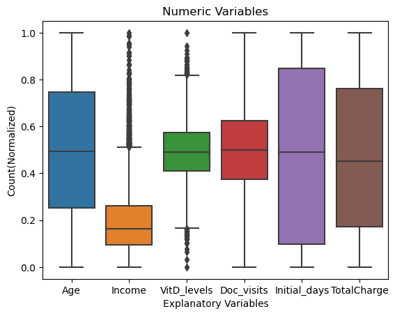

```python
# Plotting boxplots
sns.boxplot(df1_norm)
plt.title('Numeric Variables')
plt.ylabel('Count(Normalized)')
plt.xlabel('Explanatory Variables');
```

```python
# Importing SciPy library
import scipy.stats as stats

# Creating a new column for the Income and VitaminD_level z-scores
df1['Income_z_Scores'] = stats.zscore(df1['Income'])
df1['VitD_level_z_Scores'] = stats.zscore(df1['VitD_levels'])
```

```python
df1.head()
```

|  | Area | Age | Income | Marital | Gender | VitD_levels | Doc_visits | Initial_admin | Complication_risk | Overweight | Arthritis | Diabetes | Hyperlipidemia | Asthma | Services | Initial_days | TotalCharge | Income_z_Scores | VitD_level_z_Scores |
| --- | --- | --- | --- | --- | --- | --- | --- | --- | --- | --- | --- | --- | --- | --- | --- | --- | --- | --- | --- |
| 0 | Suburban | 53 | 86575.93 | Divorced | Male | 19.141466 | 6 | Emergency Admission | Medium | No | Yes | Yes | No | Yes | Blood Work | 10.585770 | 3726.702860 | 1.615914 | 0.583603 |
| 1 | Urban | 51 | 46805.99 | Married | Female | 18.940352 | 4 | Emergency Admission | High | Yes | No | No | No | No | Intravenous | 15.129562 | 4193.190458 | 0.221443 | 0.483901 |
| 2 | Suburban | 53 | 14370.14 | Widowed | Female | 18.057507 | 4 | Elective Admission | Medium | Yes | No | Yes | No | No | Blood Work | 4.772177 | 2434.234222 | -0.915870 | 0.046227 |
| 3 | Suburban | 78 | 39741.49 | Married | Male | 16.576858 | 4 | Elective Admission | Medium | No | Yes | No | No | Yes | Blood Work | 1.714879 | 2127.830423 | -0.026263 | -0.687811 |
| 4 | Rural | 22 | 1209.56 | Widowed | Female | 17.439069 | 5 | Elective Admission | Low | No | No | No | Yes | No | CT Scan | 1.254807 | 2113.073274 | -1.377325 | -0.260366 |

```python
# Creating a new dataframe with extracted Income and VitD_levels outliers
df1_no_outliers = df1[(df1['Income_z_Scores'] > -3) & (df1['Income_z_Scores'] < 3) & (df1['VitD_level_z_Scores'] > -3) & (df1['VitD_level_z_Scores'] < 3)]
```

```python
df1_no_outliers.head()
```

|  | Area | Age | Income | Marital | Gender | VitD_levels | Doc_visits | Initial_admin | Complication_risk | Overweight | Arthritis | Diabetes | Hyperlipidemia | Asthma | Services | Initial_days | TotalCharge | Income_z_Scores | VitD_level_z_Scores |
| --- | --- | --- | --- | --- | --- | --- | --- | --- | --- | --- | --- | --- | --- | --- | --- | --- | --- | --- | --- |
| 0 | Suburban | 53 | 86575.93 | Divorced | Male | 19.141466 | 6 | Emergency Admission | Medium | No | Yes | Yes | No | Yes | Blood Work | 10.585770 | 3726.702860 | 1.615914 | 0.583603 |
| 1 | Urban | 51 | 46805.99 | Married | Female | 18.940352 | 4 | Emergency Admission | High | Yes | No | No | No | No | Intravenous | 15.129562 | 4193.190458 | 0.221443 | 0.483901 |
| 2 | Suburban | 53 | 14370.14 | Widowed | Female | 18.057507 | 4 | Elective Admission | Medium | Yes | No | Yes | No | No | Blood Work | 4.772177 | 2434.234222 | -0.915870 | 0.046227 |
| 3 | Suburban | 78 | 39741.49 | Married | Male | 16.576858 | 4 | Elective Admission | Medium | No | Yes | No | No | Yes | Blood Work | 1.714879 | 2127.830423 | -0.026263 | -0.687811 |
| 4 | Rural | 22 | 1209.56 | Widowed | Female | 17.439069 | 5 | Elective Admission | Low | No | No | No | Yes | No | CT Scan | 1.254807 | 2113.073274 | -1.377325 | -0.260366 |

```python
# Dropping the Income_z_Scores and Vit_D_levels columns since
# we won't need it anymore
df1_no_outliers.drop(['Income_z_Scores', 'VitD_level_z_Scores'], axis=1, inplace=True)

df1_no_outliers.head()
```

|  | Area | Age | Income | Marital | Gender | VitD_levels | Doc_visits | Initial_admin | Complication_risk | Overweight | Arthritis | Diabetes | Hyperlipidemia | Asthma | Services | Initial_days | TotalCharge |
| --- | --- | --- | --- | --- | --- | --- | --- | --- | --- | --- | --- | --- | --- | --- | --- | --- | --- |
| 0 | Suburban | 53 | 86575.93 | Divorced | Male | 19.141466 | 6 | Emergency Admission | Medium | No | Yes | Yes | No | Yes | Blood Work | 10.585770 | 3726.702860 |
| 1 | Urban | 51 | 46805.99 | Married | Female | 18.940352 | 4 | Emergency Admission | High | Yes | No | No | No | No | Intravenous | 15.129562 | 4193.190458 |
| 2 | Suburban | 53 | 14370.14 | Widowed | Female | 18.057507 | 4 | Elective Admission | Medium | Yes | No | Yes | No | No | Blood Work | 4.772177 | 2434.234222 |
| 3 | Suburban | 78 | 39741.49 | Married | Male | 16.576858 | 4 | Elective Admission | Medium | No | Yes | No | No | Yes | Blood Work | 1.714879 | 2127.830423 |
| 4 | Rural | 22 | 1209.56 | Widowed | Female | 17.439069 | 5 | Elective Admission | Low | No | No | No | Yes | No | CT Scan | 1.254807 | 2113.073274 |

# ▶ Exploratory Data Analysis

```python
# Summary Statistics
df1_no_outliers.describe()
```

|  | Age | Income | VitD_levels | Doc_visits | Initial_days | TotalCharge |
| --- | --- | --- | --- | --- | --- | --- |
| count | 9833.000000 | 9833.000000 | 9833.000000 | 9833.000000 | 9833.000000 | 9833.000000 |
| mean | 53.525069 | 38903.649265 | 17.962174 | 5.011899 | 34.470464 | 5314.010109 |
| std | 20.638565 | 25402.245710 | 1.990759 | 1.044358 | 26.303679 | 2180.208144 |
| min | 18.000000 | 154.080000 | 11.966340 | 1.000000 | 1.001981 | 1938.312067 |
| 25% | 36.000000 | 19359.670000 | 16.631741 | 4.000000 | 7.912315 | 3181.474658 |
| 50% | 53.000000 | 33261.940000 | 17.952513 | 5.000000 | 36.221460 | 5233.963093 |
| 75% | 71.000000 | 53261.710000 | 19.339610 | 6.000000 | 61.157850 | 7460.305000 |
| max | 89.000000 | 125977.370000 | 23.941426 | 9.000000 | 71.981490 | 9180.728000 |

```python
df1_no_outliers.dtypes
```

```
Area                  object
Age                    int64
Income               float64
Marital               object
Gender                object
VitD_levels          float64
Doc_visits             int64
Initial_admin         object
Complication_risk     object
Overweight            object
Arthritis             object
Diabetes              object
Hyperlipidemia        object
Asthma                object
Services              object
Initial_days         float64
TotalCharge          float64
dtype: object
```

## Univariate Analysis

### Numeric Variables

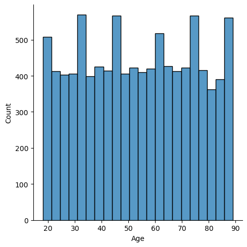

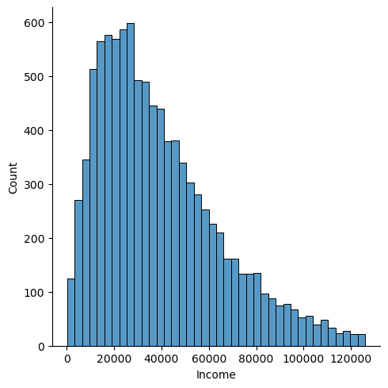

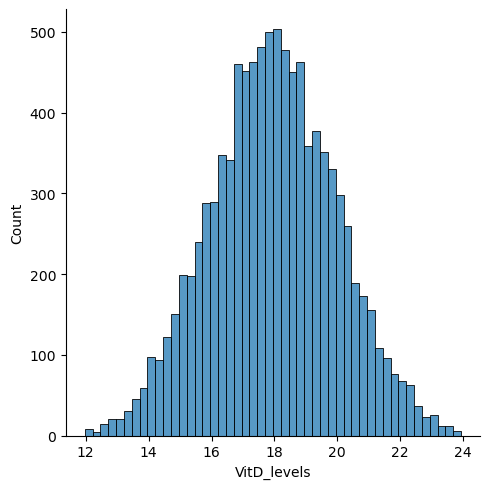

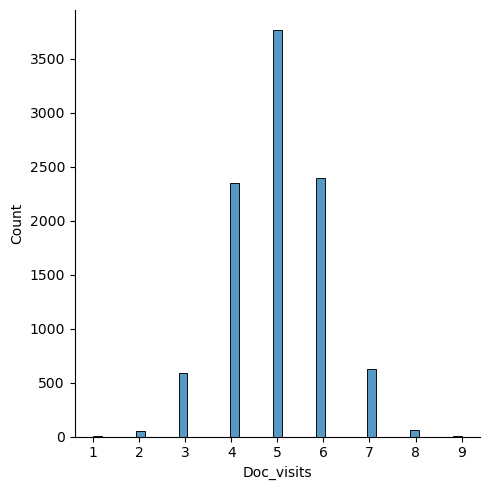

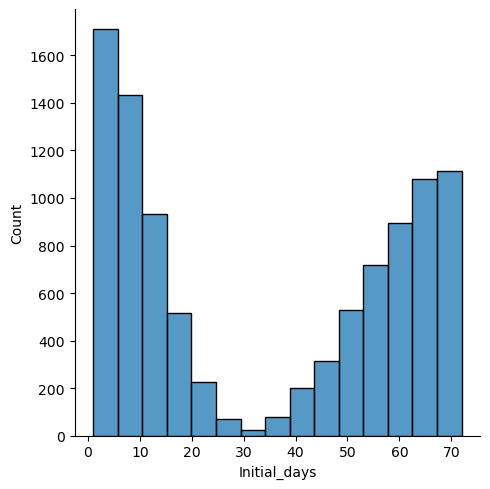

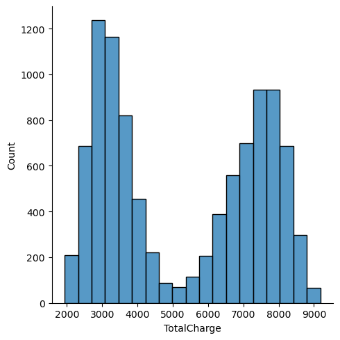

```python
# Univariate analysis visualizations for numerical variables
sns.displot(df1_no_outliers['Age']);
sns.displot(df1_no_outliers['Income']);
sns.displot(df1_no_outliers['VitD_levels']);
sns.displot(df1_no_outliers['Doc_visits']);
sns.displot(df1_no_outliers['Initial_days']);
sns.displot(df1_no_outliers['TotalCharge']);
```

### Categorical Variables

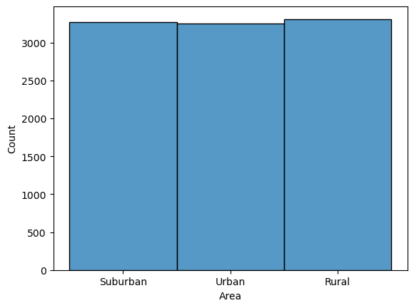

```python
sns.histplot(df1_no_outliers['Area']);
```

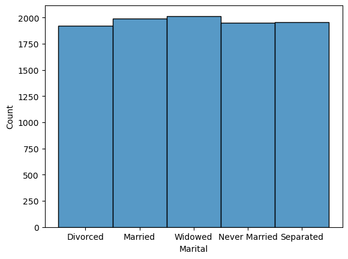

```python
sns.histplot(df1_no_outliers['Marital']);
```

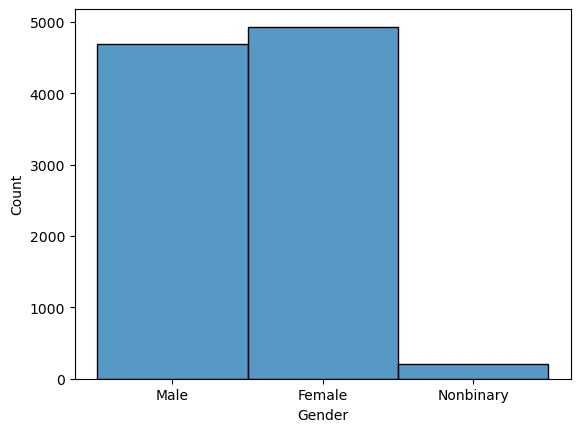

```python
sns.histplot(df1_no_outliers['Gender']);
```

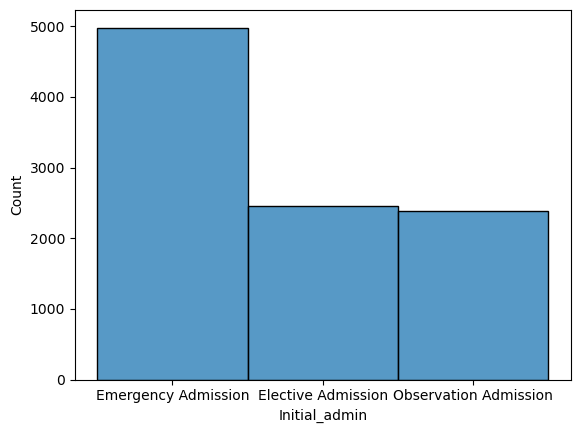

```python
sns.histplot(df1_no_outliers['Initial_admin']);
```

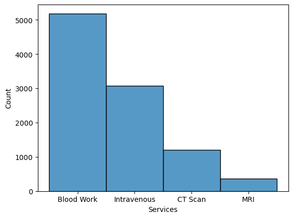

```python
sns.histplot(df1_no_outliers['Services']);
```

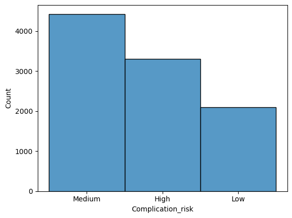

```python
sns.histplot(df1_no_outliers['Complication_risk']);
```

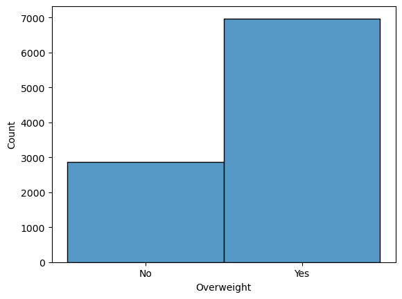

```python
sns.histplot(df1_no_outliers['Overweight']);
```

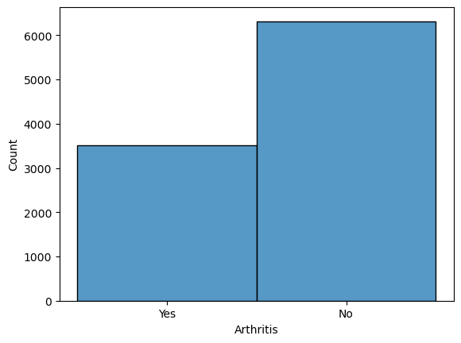

```python
sns.histplot(df1_no_outliers['Arthritis']);
```

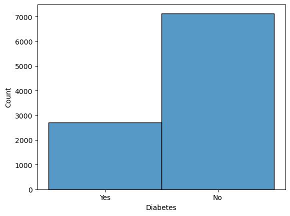

```python
sns.histplot(df1_no_outliers['Diabetes']);
```

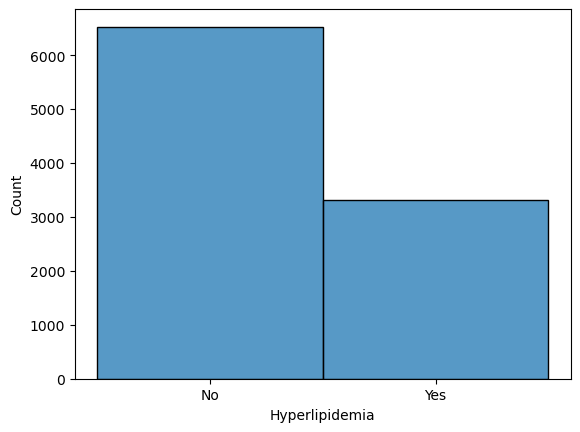

```python
sns.histplot(df1_no_outliers['Hyperlipidemia']);
```

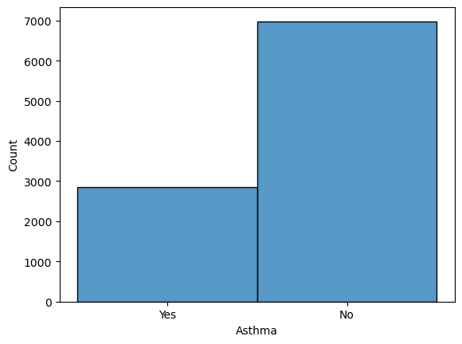

```python
sns.histplot(df1_no_outliers['Asthma']);
```

## Bivariate Analysis

### Numeric Variables

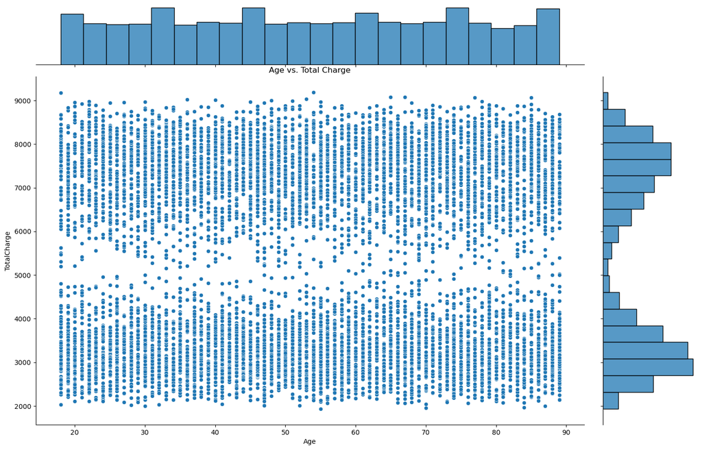

```python
# Bivariate analysis visualizations for Age vs Total_Charge
sns.jointplot(data=df1_no_outliers, x='Age', y='TotalCharge')
plt.title('Age vs. Total Charge')
fig = plt.gcf()
fig.set_size_inches(16, 10);
```

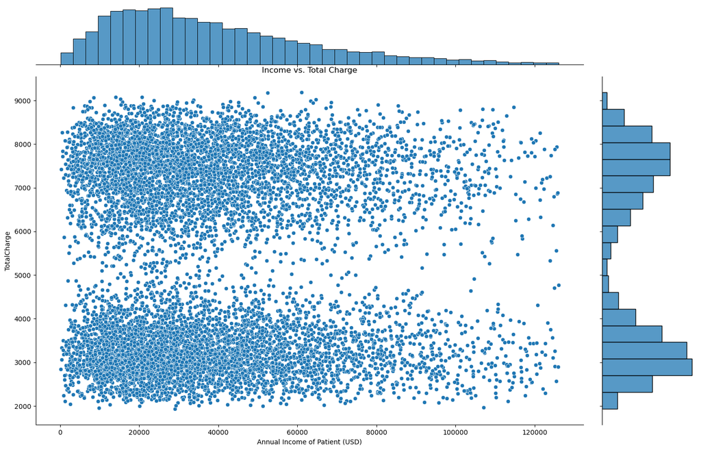

```python
# Income vs Total Charge
sns.jointplot(data=df1_no_outliers, x='Income', y='TotalCharge')
plt.title('Income vs. Total Charge')
plt.xlabel('Annual Income of Patient (USD)')
fig = plt.gcf()
fig.set_size_inches(16, 10);
```

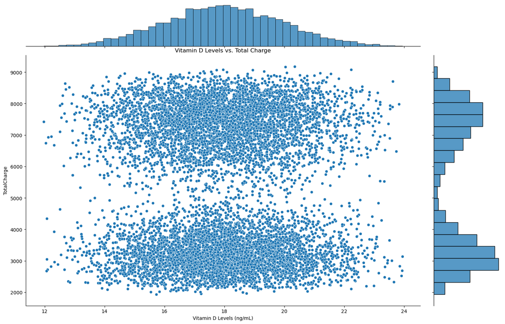

```python
# VitaminD Levels vs Total Charge
sns.jointplot(data=df1_no_outliers, x='VitD_levels', y='TotalCharge')
plt.title('Vitamin D Levels vs. Total Charge')
plt.xlabel('Vitamin D Levels (ng/mL)')
fig = plt.gcf()
fig.set_size_inches(16, 10);
```

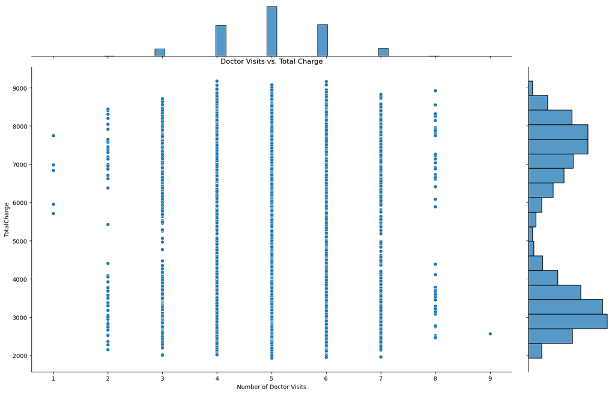

```python
# Doc-Visits vs Total Charge
sns.jointplot(data=df1_no_outliers, x='Doc_visits', y='TotalCharge')
plt.title('Doctor Visits vs. Total Charge')
plt.xlabel('Number of Doctor Visits')
fig = plt.gcf()
fig.set_size_inches(16, 10);
```

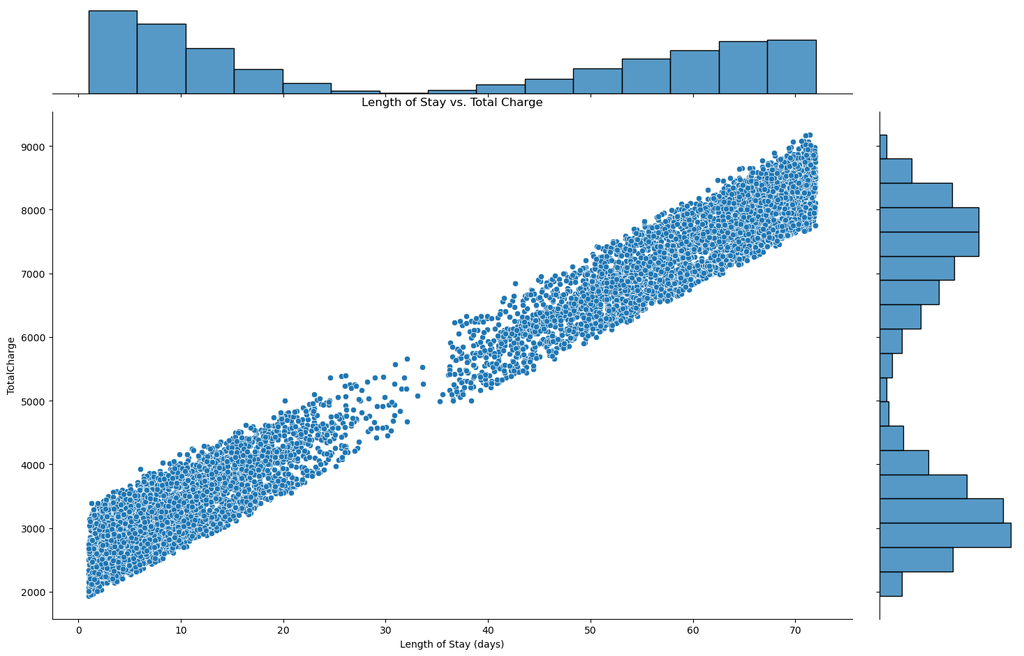

```python
# Doc-Visits vs Total Charge
sns.jointplot(data=df1_no_outliers, x='Initial_days', y='TotalCharge')
plt.title('Length of Stay vs. Total Charge')
plt.xlabel('Length of Stay (days)')
fig = plt.gcf()
fig.set_size_inches(16, 10);
```